# Reproducible Research Peer Assessment 2

Yilmaz Rona

October 20, 2015

# Data Analysis

[The original dataset is published on the Internet[46.9 Mb].](https://d396qusza40orc.cloudfront.net/repdata%2Fdata%2FStormData.csv.bz2)

If one inspects the original data set, one observes that the EVTYPE field is poorly validated; Spelling errors and capitalization differences and non standard terminology abound. Through inspection of the data set, I generated a mapping of each meaningful event entry into a handful of different event categories. The types of events are Temperature Events, Precipitation Events, Wind Events, Electrical Events, Flooding Events, Maritime Events, Erosion Events and Combustion Events.

It is important to note that the same incident can appear in multiple categories, if, for example, a person is struck by lightning during a thunderstorm, their death will be tabulated as a fatality associated with a lightning event and as a fatality associated with thunderstorms.

In calculating economic damage, the dollar amounts of crop damage and property damage were added together. To find the property and crop damage, we used the exponent mapping below:

```
##    Code Multiplier
## 1     -          1
## 2     ?          0
## 3     +          0
## 4     0         10
## 5     1         10
## 6     2         10
## 7     3         10
## 8     4         10
## 9     5         10
## 10    6         10
## 11    7         10
## 12    8         10
## 13    B 1000000000
## 14    h        100
## 15    H        100
## 16    K       1000
## 17    m    1000000
## 18    M    1000000
```

# Results

## Types of Events

```
##        category
## 1   Temperature
## 2 Precipitation
## 3         Winds
## 4    Electrical
## 5      Flooding
## 6      Maritime
## 7       Erosion
## 8    Combustion
```

## Specific Hazards

In order to examine which specific events cause the greatest economic damage and cause the most deaths, the fatalities and economic damage for each of the specific categories developed during the mapping above were combined in a single table, listing each category along with the fatalities and economic damage associated with each.

The greatest hazards to life based on historical fatalities are charted below:

```
##          EVENT FATALITIES INJURIES   ECONDAMAGE
## 1      TORNADO       5661    91410  59010758047
## 2         HEAT       3117     9174    924789250
## 3      DROUGHT       1907     6544  15519077700
## 4  FLASH FLOOD       1505     8591 168759746603
## 5    LIGHTNING        817     5232    951116507
## 6 THUNDERSTORM        750     9517  13851676522
## 7         WIND        721     8403   7494173552
## 8  RIP CURRENT        572      529       163000
```

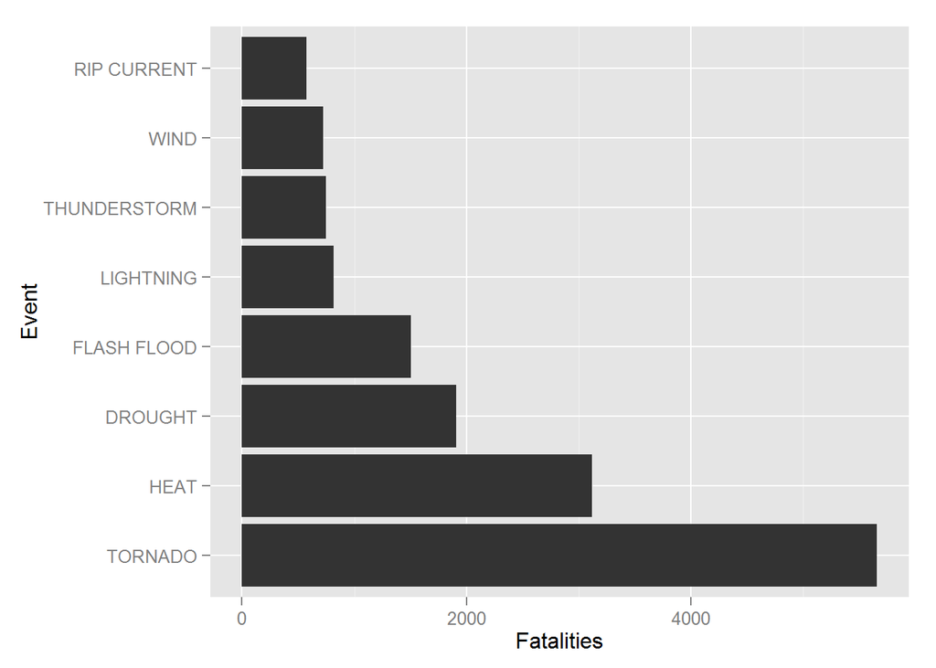

The greatest hazards to property and crops are charted below:

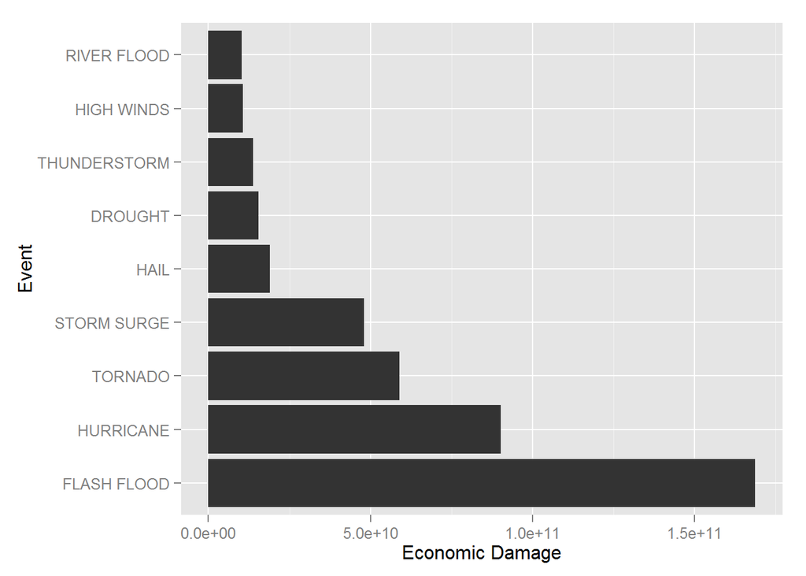

For the emergency planner, flash floods, hurricanes and tornados are the greatest threats to property. Coastal areas are at greatest risk, with additional dangers posed by storm surges. The greatest threats to life and limb are due to tornados, which can strike with little warning, followed by heat waves, drought, and flash floods.